# PhD Chapter 3 - RelativeSize

Emanuele Giacomuzzo

2024-10-07 21:24

## Design

[figure not shown]

## Parameters

Parameters for R markdown and the general running of the code.

```r
knitr::opts_chunk$set(message = FALSE,
                      cache = FALSE,
                      autodep = FALSE)
start_time = Sys.time()
recompute_analyses = FALSE
```

Parameters necessary to use the package BEMOVI (includes sampling parameters).

```r
fps = 25 #Frames per second
seconds_per_video = 5
total_frames = fps * seconds_per_video
measured_volume = 34.4 #volume measured for each video in µL
volume_recorded_μl = measured_volume
volume_recorded_ml = volume_recorded_μl * 10^-3
pixel_to_scale = 4.05
filter_min_net_disp = 25
filter_min_duration = 1
filter_detection_freq = 0.1
filter_median_step_length = 3

time_points = 0:7
sampling_days = c(0, 4, 8, 12, 16, 20, 24, 28)

threshold_levels = c(13, 40) #These are the two lower threshold for pixel intensity for imageJ to distinguish between background and foreground. We analysed the videos using 13 as the minimum threshold, then did the same with 40.

video.description.folder = "0_video_description/"
video.description.file = "video_description.txt"
merged_data_folder = "5_merged_data/"

columns_for_species_ID = c("mean_grey",
                           "sd_grey",
                           "mean_area",
                           "sd_area",
                           "mean_perimeter",
                           "mean_turning",
                           "sd_turning",
                           "sd_perimeter",
                           "mean_major",
                           "sd_major",
                           "mean_minor",
                           "sd_minor",
                           "mean_ar",
                           "sd_ar",
                           "duration",
                           "max_net",
                           "net_disp",
                           "net_speed",
                           "gross_disp",
                           "max_step",
                           "min_step",
                           "sd_step",
                           "sd_gross_speed",
                           "max_gross_speed",
                           "min_gross_speed")
```

Parameters related to resource flows.

```r
resource_flow_days = c(5, 9, 13, 17, 21, 25)
size_effect_types = c("fixed", "decreasing_with_size")
fixed_label = "Disturbance percentage FIXED"
relative_label = "Disturbance percentage DECREASING WITH SIZE"
```

Parameters related to protists.

```r
protist_species = c("Ble", "Cep", "Col", "Eug", "Eup", "Lox", "Pau", "Pca", "Spi", "Spi_te", "Tet")
protist_species_indiv_per_ml = paste0(protist_species, "_indiv_per_ml")
protist_species_bioarea_mm2_per_ml = paste0(protist_species, "_bioarea_mm2_per_ml")
protist_species_dominance = paste0(protist_species_bioarea_mm2_per_ml, "_dominance")
species_IDD_with_13_threshold = c("Col", "Cep", "Eup", "Lox", "Pau", "Pca", "Spi_te", "Tet")
species_IDD_with_40_threshold = c("Ble", "Spi")
```

Parameters related to ecosystems.

```r
ds_ecosystems = NULL
ds_ecosystems_effect_size = NULL
ecosystems_to_take_off = NA

connection_ordered = c("unconnected", "connected")
ecosystem_sizes_ml = c(6.43, 9.00, 15.00, 45.00)

ecosystem_info = read.csv(here("1_data", "ecosystem_info.csv"), header = TRUE) %>%
  rename(ecosystem_ID = culture_ID,
         ecosystem_type = eco_metaeco_type,
         ecosystem_size_ml = patch_size_ml) %>%
  mutate(connection = factor(x = ifelse(metaecosystem == "yes",
                                        "connected",
                                        "unconnected"),
                             levels = connection_ordered),
         disturbance_percentage = factor(x = ifelse(flow == "absolute",
                                                    "decreasing_with_size",
                                                    "fixed"))) %>%
  select(ecosystem_ID,
         system_nr,
         ecosystem_size_ml,
         trophic_type,
         connection,
         disturbance_percentage)

n_ecosystems = max(ecosystem_info$ecosystem_ID)

variables_ecosystems = c("bioarea_mm2_per_ml",
                        "indiv_per_ml",
                        "species_richness",
                        "shannon",
                        "evenness_pielou",
                        protist_species_indiv_per_ml,
                        protist_species_dominance)
```

Parameters related to meta-ecosystems.

```r
ds_metaecosystems = NULL
metaecosystems_to_take_off = NA

system_nr_metaecosystems = ecosystem_info %>%
  filter(connection == "connected") %>%
  pull(system_nr) %>%
  unique

n_metaecosystems = length(system_nr_metaecosystems)

variables_metaecos = c("total_metaecosystem_bioarea_mm2")

unconnected_metaecosystems = data.frame(system_type = as.character(NA),
                                        autotrophic_ecosystem_IDs = as.character(NA),
                                        heterotrophic_ecosystem_IDs = as.character(NA)) %>%
  slice(-1)

# for(row in 1:nrow(names)) {
#
#   unconnected_metaecosystems = unconnected_metaecosystems %>%
#     add_row(system_type = names$system_type[row],
#             autotrophic_ecosystem_IDs = ecosystem_info %>%
#               filter(eco_metaeco_type == names$autotrophic_ecosystem[row]) %>%
#               pull(ecosystem_ID) %>%
#               paste(., collapse = ", "),
#             heterotrophic_ecosystem_IDs = ecosystem_info %>%
#               filter(eco_metaeco_type == names$heterotrophic_ecosystem[row]) %>%
#               pull(ecosystem_ID) %>%
#               paste(., collapse = ", "))
# }
#
unconnected_metaecosystems_selected = c("1|7",
                                        "2|8",
                                        "3|9",
                                        "4|10",
                                        "5|11",
                                        "6|12",

                                        "13|19",
                                        "14|20",
                                        "15|21",
                                        "16|22",
                                        "17|23",
                                        "18|24",

                                        "25|31",
                                        "26|32",
                                        "27|33",
                                        "28|34",
                                        "29|35",
                                        "30|36",

                                        "37|43",
                                        "38|44",
                                        "39|45",
                                        "40|46",
                                        "41|47",
                                        "42|48",

                                        "97|103",
                                        "98|104",
                                        "99|105",
                                        "100|106",
                                        "101|107",
                                        "102|108",

                                        "109|115",
                                        "110|116",
                                        "111|117",
                                        "112|118",
                                        "113|119",
                                        "114|120",

                                        "121|127",
                                        "122|128",
                                        "123|129",
                                        "124|130",
                                        "125|131",
                                        "126|132",

                                        "133|139",
                                        "134|140",
                                        "135|141",
                                        "136|142",
                                        "137|143",
                                        "138|144")
```

Name of the axes per response variable.

```r
axis_names = data.frame(variable = NA,
                        axis_name= NA) %>%
  add_row(variable = "day", axis_name = "Time (day)") %>%
  add_row(variable = "ecosystem_size_ml", axis_name = "Ecosystem Size (ml)") %>%
  add_row(variable = "bioarea_mm2_per_ml", axis_name = "Biomass Density (mm²/ml)") %>%
  add_row(variable = "bioarea_mm2_per_ml_d", axis_name = "Biomass Density ES (Hedge's d)") %>%
  add_row(variable = "bioarea_tot", axis_name = "Total Biomass (mm²)") %>%
  add_row(variable = "species_richness", axis_name = "Species Richness") %>%
  add_row(variable = "species_richness_d", axis_name = "Species Richness ES") %>%
  add_row(variable = "shannon", axis_name = "Shannon Index") %>%
  add_row(variable = "shannon_d", axis_name = "Shannon Index ES") %>%
  add_row(variable = "evenness_pielou", axis_name = "Evenness (Pielou's Index)") %>%
  add_row(variable = "evenness_pielou_d", axis_name = "Evenness ES") %>%
  add_row(variable = "log_abundance", axis_name = "Log Abundance + 1 (ind/mm²)") %>%
  add_row(variable = "abundance_hedges_d", axis_name = "Density ES") %>%
  add_row(variable = "indiv_per_ml", axis_name = "Abundance (ind/ml)") %>%
  add_row(variable = "indiv_per_ml_d", axis_name = "Abundance ES") %>%
  add_row(variable = "Ble_indiv_per_ml", axis_name = "Ble Density (ind/ml)") %>%
  add_row(variable = "Cep_indiv_per_ml", axis_name = "Cep Density (ind/ml)") %>%
  add_row(variable = "Col_indiv_per_ml", axis_name = "Col Density (ind/ml)") %>%
  add_row(variable = "Eug_indiv_per_ml", axis_name = "Eug Density (ind/ml)") %>%
  add_row(variable = "Eup_indiv_per_ml", axis_name = "Eup Density (ind/ml)") %>%
  add_row(variable = "Lox_indiv_per_ml", axis_name = "Lox Density (ind/ml)") %>%
  add_row(variable = "Pau_indiv_per_ml", axis_name = "Pau Density (ind/ml)") %>%
  add_row(variable = "Pca_indiv_per_ml", axis_name = "Pca Density (ind/ml)") %>%
  add_row(variable = "Spi_indiv_per_ml", axis_name = "Spi Density (ind/ml)") %>%
  add_row(variable = "Spi_te_indiv_per_ml", axis_name = "Spi te Density (ind/ml)") %>%
  add_row(variable = "Tet_indiv_per_ml", axis_name = "Tet Density (ind/ml)") %>%
  add_row(variable = "Ble_indiv_per_ml_d", axis_name = "Ble Density ES") %>%
  add_row(variable = "Cep_indiv_per_ml_d", axis_name = "Cep Density ES") %>%
  add_row(variable = "Col_indiv_per_ml_d", axis_name = "Col Density ES") %>%
  add_row(variable = "Eug_indiv_per_ml_d", axis_name = "Eug Density ES") %>%
  add_row(variable = "Eup_indiv_per_ml_d", axis_name = "Eup Density ES") %>%
  add_row(variable = "Lox_indiv_per_ml_d", axis_name = "Lox Density ES") %>%
  add_row(variable = "Pau_indiv_per_ml_d", axis_name = "Pau Density ES") %>%
  add_row(variable = "Pca_indiv_per_ml_d", axis_name = "Pca Density ES") %>%
  add_row(variable = "Spi_indiv_per_ml_d", axis_name = "Spi Density ES") %>%
  add_row(variable = "Spi_te_indiv_per_ml_d", axis_name = "Spi te Density ES") %>%
  add_row(variable = "Tet_indiv_per_ml_d", axis_name = "Tet Density ES") %>%
  add_row(variable = "dominance", axis_name = "Dominance (%)") %>%
  add_row(variable = "Ble_indiv_per_ml_dominance", axis_name = "Ble Dominance (%)") %>%
  add_row(variable = "Cep_indiv_per_ml_dominance", axis_name = "Cep Dominance (%)") %>%
  add_row(variable = "Col_indiv_per_ml_dominance", axis_name = "Col Dominance (%)") %>%
  add_row(variable = "Eug_indiv_per_ml_dominance", axis_name = "Eug Dominance (%)") %>%
  add_row(variable = "Eup_indiv_per_ml_dominance", axis_name = "Eup Dominance (%)") %>%
  add_row(variable = "Lox_indiv_per_ml_dominance", axis_name = "Lox Dominance (%)") %>%
  add_row(variable = "Pau_indiv_per_ml_dominance", axis_name = "Pau Dominance (%)") %>%
  add_row(variable = "Pca_indiv_per_ml_dominance", axis_name = "Pca Dominance (%)") %>%
  add_row(variable = "Spi_indiv_per_ml_dominance", axis_name = "Spi Dominance (%)") %>%
  add_row(variable = "Spi_te_indiv_per_ml_dominance", axis_name = "Spi te Dominance (%)") %>%
  add_row(variable = "Tet_indiv_per_ml_dominance", axis_name = "Tet Dominance (%)") %>%
  add_row(variable = "Ble_indiv_per_ml_dominance_d", axis_name = "Ble Dominance ES") %>%
  add_row(variable = "Cep_indiv_per_ml_dominance_d", axis_name = "Cep Dominance ES") %>%
  add_row(variable = "Col_indiv_per_ml_dominance_d", axis_name = "Col Dominance ES") %>%
  add_row(variable = "Eug_indiv_per_ml_dominance_d", axis_name = "Eug Dominance ES") %>%
  add_row(variable = "Eup_indiv_per_ml_dominance_d", axis_name = "Eup Dominance ES") %>%
  add_row(variable = "Lox_indiv_per_ml_dominance_d", axis_name = "Lox Dominance ES") %>%
  add_row(variable = "Pau_indiv_per_ml_dominance_d", axis_name = "Pau Dominance ES") %>%
  add_row(variable = "Pca_indiv_per_ml_dominance_d", axis_name = "Pca Dominance ES") %>%
  add_row(variable = "Sp_indiv_per_mli_dominance_d", axis_name = "Spi Dominance ES") %>%
  add_row(variable = "Spi_te_indiv_per_ml_dominance_d", axis_name = "Spi te Dominance ES") %>%
  add_row(variable = "Tet_indiv_per_ml_dominance_d", axis_name = "Tet Dominance ES") %>%
  add_row(variable = "log_size_class", axis_name = "Log Size (μm2)") %>%
  add_row(variable = "class_indiv_per_µl", axis_name = "Density (ind/ml)") %>%
  add_row(variable = "median_body_area_µm2", axis_name = "Median Body Size (µm²)") %>%
  add_row(variable = "median_body_area_µm2_d", axis_name = "Median Body Size ES") %>%
  add_row(variable = "beta_diversity_from_unconnected", axis_name = "Divergence from unconnected") %>%

  add_row(variable = "total_metaecosystem_bioarea_mm2", axis_name = "Total Biomass (mm²)") %>%
  add_row(variable = "total_metaecosystem_bioarea_mm2_d", axis_name = "Total Biomass ES (Hedge's d)") %>%

  slice(-1)
```

```r
treatment_colours_metaecosystems = c("6.43 ml" = "#ffeda0",
                                     "9.00 ml" = "#fecc5c",
                                     "15.00 ml" = "#fd8d3c",
                                     "45.00 ml" = "#e31a1c")

treatment_colours_autotrophic = c("6.43 ml" = "#e5f5e0",
                                  "9.00 ml" = "#b2e2e2",
                                  "15.00 ml" = "#66c2a4",
                                  "45.00 ml" = "#238b45")

treatment_colours_heterotrophic = c("6.43 ml" = "#deebf7",
                                    "9.00 ml" = "#bdd7e7",
                                    "15.00 ml" = "#6baed6",
                                    "45.00 ml" = "#2171b5")

treatment_linetypes = c("connected" = "solid",
                        "unconnected" = "longdash")
```

Parameters for plotting.

```r
figures_width_rmd_output = 10
figures_height_rmd_output = 8

legend_position = "top"
legend_width_cm = 2
size_legend = 12
size_x_axis = 16
size_y_axis = 14
boxplot_width = 2
dodging = 0.5
width_errorbar = 2
dodging_error_bar = 0.5

treatment_lines_linewidth = 1
treatment_points_size = 2.5

resource_flow_line_type = "solid"
resource_flow_line_colour = "#d9d9d9"
resource_flow_line_width = 0.3

zero_line_colour = "grey"
zero_line_line_type = "dotted"
zero_line_line_width = 0.5
zero_line_ES_line_type = "dotted"
zero_line_ES_colour = "grey"
zero_line_ES_line_width = 1

ggarrange_margin_top = 0
ggarrange_margin_bottom = 0
ggarrange_margin_left = 0
ggarrange_margin_right = 0

paper_labels_size = 12
paper_width = 17.3
paper_height = 20
paper_units = "cm"
paper_res = 600

presentation_figure_size = 15
presentation_figure_width = 30
presentation_figure_height = 22
presentation_legend_size = 20
presentation_x_axis_size = 20
presentation_y_axis_size = presentation_x_axis_size
presentation_treatment_points_size = 5
presentation_treatment_linewidth = 2
presentation_figure_units = "cm"
presentation_figure_res = 600

grey_background_xmin = -Inf
grey_background_xmax = 7.5
grey_background_ymin = -Inf
grey_background_ymax = Inf
grey_background_fill = "#f0f0f0"
grey_background_alpha = 0.03
grey_background_color = "transparent"
```

Parameters for modelling.

```r
first_time_point_model = 2 #Time point 2 is the first after disturbance
last_time_point_model = time_points[length(time_points)]
iterated_results_table = NULL

optimizer_input = 'Nelder_Mead'
method_input = ''

results_table = data.frame(Response = as.character(NA),
                           Levels = as.character(NA),
                           ΔAIC_full = NA,
                           p_full = NA,
                           ΔR2_full = NA,
                           ΔAIC_fix = NA,
                           p_fix = NA,
                           ΔR2_fix = NA) %>%
  slice(-1)

iterated_results_table = data.frame(Response = as.character(NA),
                                    Levels = as.character(NA),
                                    ΔAIC_full = NA,
                                    p_full = NA,
                                    ΔR2_full = NA,
                                    ΔAIC_fix = NA,
                                    p_fix = NA,
                                    ΔR2_fix = NA,
                                    combination_set = NA) %>%
  slice(-1)
```

## Data

### Individuals (`ds_individuals`)

```r
# --- IMPORT DATASETS --- #

ds_individuals = NULL
for(time_point in time_points){

  # Import the master data (aka particles data) where particles in each video have been tracked.
  # We use time_point + 1 because our first time point is 0 and we cannot assign an object to ds_individuals[[0]], as the index of a dataset in R needs to be an integer >= 1.

  ds_individuals[[time_point + 1]] = read.csv(here("1_data",
                                                   "13_threshold_analysis",
                                                   paste0("t", time_point, ".csv"))) %>%

    # To keep consistent with the term "ecosystem", rename culture ID to ecosystem ID.

    rename(ecosystem_ID = culture_ID) %>%

    mutate(

      # To don't create rows with unnecessary NAs, remove the column "comment", as no entry received a comment in the experiment.

      comment = NULL,

      # To have everything in mm2 and ml, transform bioarea columns.

      bioarea_µm2 = mean_area,
      bioarea_mm2 = bioarea_µm2 * 10^-6,
      bioarea_mm2_per_ml = bioarea_mm2 / volume_recorded_ml,
      bioarea_mm2_per_frame_per_ml = bioarea_mm2_per_ml * N_frames / total_frames) %>%

    # To tidy up, reorder columns.

    select(time_point,
           day,
           ecosystem_ID,
           id,
           everything())
}
```

```r
## - (2) Bind time points - ##

ds_individuals = ds_individuals %>%
  bind_rows()
```

```r
## - (3) Finish up ds_individuals - ##

ds_individuals = ds_individuals %>%

  # To have all the information on the ecosystems that were not in the original data, bind 'ds_individuals' with 'ecosystem_info'.

  left_join(ecosystem_info,
            by = "ecosystem_ID") %>%

  # To tidy up, reorder columns.

  select(time_point,
         day,
         system_nr,
         ecosystem_ID,
         ecosystem_size_ml,
         trophic_type,
         connection,
         disturbance_percentage,
         bioarea_mm2,
         bioarea_mm2_per_frame_per_ml,
         N_frames,
         all_of(columns_for_species_ID))
```

We have now completed the assembly of the dataset containing all individuals in the experiment (ds_individuals), each linked with morphological and behavioral traits. We then construct a support vector machine model capable of identifying a protist species based on these traits, as we have recorded the mono-cultures of species just prior to the experiment. To do so, we must go through the following steps. (1) Create training dataset. Import the training dataset comprising monoculture data and modify it so that it can be used to construct the predictive model. (2) Create predictive model. Construct a predictive model for species identification using support vector machines and all traits we have measured. (3) Show confusion matrix. To see with what precision species are identified, let’s plot the confusion matrix of this model. In this matrix, the class error tells us with what percentage individuals of a species are misidentified. (4) Identify species. Identify protist individuals in ds_individuals.

```r
# --- CREATE TRAINING DATASET --- #

training_individuals = NULL
for(threshold_i in 1:length(threshold_levels)){

  # Import the master (aka particles) data where particles in each video have been tracked.

  training_individuals[[threshold_i]] = read.csv(here("1_data",
                                                      paste0(threshold_levels[threshold_i],
                                                             "_threshold_analysis"),
                                                      "training.csv")) %>%

  # To increase the precision of the model, exclude Eug from the training monocultures, as we don't want species in heterotrophic to be mistaken for Euglena, as Euglena was not present in there. It doesn't matter how species in autotrophic ecosystems are identified, as we will change them anyway to Euglena.

  filter(species != "Eug") %>%

  # To make it easier to handle the level, transform Spi te into Spi_te.

  mutate(species = case_when(species == "Spi te" ~ "Spi_te",
                             TRUE ~ species),

  # To don't create rows with unnecessary NAs, remove the column "comment", as no entry received a comment in the experiment.

         comment = NULL,

  # ...

         file = as.numeric(str_extract(file, "\\d+"))) %>%

  # To don't have particles where some values couldn't be computed, remove rows that have NAs.

  filter(complete.cases(.)) %>%

  # To tidy up, reorder columns.

  select(file,
         id,
         species,
         N_frames,
         mean_area,
         everything())

}

ds_individuals_13 = training_individuals[[1]] %>%
  filter(!species == "Ble")

ds_individuals_40 = training_individuals[[2]] %>%
  filter(species == "Ble")

training_individuals = rbind(ds_individuals_13,
                             ds_individuals_40)
```

```r
## - (2) Create predictive model - ##

species_ID_model = svm(factor(species) ~
                         mean_grey +
                         sd_grey +
                         mean_area +
                         sd_area +
                         mean_perimeter +
                         mean_turning +
                         sd_turning +
                         sd_perimeter +
                         mean_major +
                         sd_major +
                         mean_minor +
                         sd_minor +
                         mean_ar +
                         sd_ar +
                         duration +
                         max_net  +
                         net_disp +
                         net_speed +
                         gross_disp +
                         max_step +
                         min_step +
                         sd_step +
                         sd_gross_speed +
                         max_gross_speed +
                         min_gross_speed ,
                       data = training_individuals,
                       probability = T,
                       na.action = na.pass)
```

```r
## - (3) Show confusion matrix - ##

confusion_matrix = table(species_ID_model$fitted,
                         training_individuals$species)

confusion_matrix_with_diagonal_zeros = confusion_matrix
diag(confusion_matrix_with_diagonal_zeros) = 0

confusion_matrix = cbind(confusion_matrix,
                         class_error = rowSums(confusion_matrix_with_diagonal_zeros) /
                                       rowSums(confusion_matrix)) %>%
  as.data.frame() %>%
  mutate(class_error_percentage = class_error * 100,
         class_error = NULL)

confusion_matrix
```

```
##        Ble Cep Col Eup Lox Pau Pca Spi Spi_te Tet class_error_percentage
## Ble    147   0   0   0   0   2   1   1      1   0              3.2894737
## Cep      4 136   4   4   0   7   3   4     13   1             22.7272727
## Col      0   0 235   0   0   0   0   0      1   0              0.4237288
## Eup      1   0   1 147   0   3   0   5      1   0              6.9620253
## Lox      0   2   0   3 237   0   0   0      0   2              2.8688525
## Pau      1   1   0   1   0 106   1   1      2   0              6.1946903
## Pca      0   0   1   1   0  10 188   2      0   0              6.9306931
## Spi      1   1   4   4   1   0   4 168      1   0              8.6956522
## Spi_te   1   0   0   0   0   1   1   0    139   0              2.1126761
## Tet      0   0   1   2  15   0   0  23      7 937              4.8730964
```

```r
## - (4) Identify species - ##

ds_individuals = ds_individuals %>%
  filter(complete.cases(.)) %>%
  mutate(species = as.character(predict(object = species_ID_model,
                                        .,
                                        type = "response")),
         species = ifelse(trophic_type == "autotrophic",
                          "Eug",
                          species),

         # To make it easier to handle the level, transform Spi te into Spi_te.

         species = case_when(species == "Spi te " ~ "Spi_te",
                             TRUE ~ species))
```

### Ecosystems (`ds_ecosystems`)

```r
ds_ecosystems = ds_individuals %>%

  # To afterwards calculate the biomass and individuals of an ecosystem, summarise the bioarea and individuals of each species.

  group_by_at(vars(time_point:disturbance_percentage,
                   species)) %>%
  summarise(bioarea_mm2_per_ml = sum(bioarea_mm2_per_frame_per_ml),
            indiv_per_ml = sum(N_frames) / total_frames) %>%

  # To make it easier to plot and analyse the dataset, go from a long format (each row is a species of an ecosystem at a time point) to a wide format (each row is an ecosystem at a time point).

  pivot_wider(names_from = species,
              values_from = c(bioarea_mm2_per_ml,
                              indiv_per_ml)) %>%
  rename(Ble_indiv_per_ml = indiv_per_ml_Ble,
         Cep_indiv_per_ml = indiv_per_ml_Cep,
         Col_indiv_per_ml = indiv_per_ml_Col,
         Tet_indiv_per_ml = indiv_per_ml_Tet,
         Eug_indiv_per_ml = indiv_per_ml_Eug,
         Eup_indiv_per_ml = indiv_per_ml_Eup,
         Lox_indiv_per_ml = indiv_per_ml_Lox,
         Pau_indiv_per_ml = indiv_per_ml_Pau,
         Pca_indiv_per_ml = indiv_per_ml_Pca,
         Spi_indiv_per_ml = indiv_per_ml_Spi,
         Spi_te_indiv_per_ml = indiv_per_ml_Spi_te,
         Ble_bioarea_mm2_per_ml = bioarea_mm2_per_ml_Ble,
         Col_bioarea_mm2_per_ml = bioarea_mm2_per_ml_Col,
         Cep_bioarea_mm2_per_ml = bioarea_mm2_per_ml_Cep,
         Eug_bioarea_mm2_per_ml = bioarea_mm2_per_ml_Eug,
         Eup_bioarea_mm2_per_ml = bioarea_mm2_per_ml_Eup,
         Lox_bioarea_mm2_per_ml = bioarea_mm2_per_ml_Lox,
         Pau_bioarea_mm2_per_ml = bioarea_mm2_per_ml_Pau,
         Pca_bioarea_mm2_per_ml = bioarea_mm2_per_ml_Pca,
         Spi_bioarea_mm2_per_ml = bioarea_mm2_per_ml_Spi,
         Spi_te_bioarea_mm2_per_ml = bioarea_mm2_per_ml_Spi_te,
         Tet_bioarea_mm2_per_ml = bioarea_mm2_per_ml_Tet)

# To have a single value at time point 0, average the values of all the videos.

ds_ecosystems = ds_ecosystems %>%
  group_by_at(vars(time_point:disturbance_percentage)) %>%
  summarise(across(contains("bioarea_mm2_per_ml"),
                   sum,
                   na.rm = TRUE),
            across(contains("indiv_per_ml"),
                    sum,
                   na.rm = TRUE)) %>%

  mutate(

         # Calculate biomass and individuals of single ecosystems.

         indiv_per_ml = sum(across(contains("indiv_per_ml"))),
         bioarea_mm2_per_ml = sum(across(contains("bioarea_mm2_per_ml"))),

         # To then sum bioarea between ecosystems of the same meta-ecosystem, get total bioarea.

         bioarea_tot_mm2 = bioarea_mm2_per_ml * ecosystem_size_ml,

         # To study how the connection influenced biodiversity, calculate species richness, Shannon index, and evenness.

         species_richness = specnumber(across(ends_with("_indiv_per_ml"))),
         shannon = diversity(across(ends_with("_indiv_per_ml")),
                             index = "shannon"),
         shannon = ifelse(species_richness == 0,
                          yes = NA,
                          no = shannon),
         evenness_pielou = shannon / log(species_richness)) %>%

  # To have a single value for each ecosystem at a time point, average video replicates.

  group_by(across(all_of(c("time_point",
                           "day",
                           "system_nr",
                           "ecosystem_ID",
                           "trophic_type",
                           "ecosystem_size_ml",
                           "connection",
                           "disturbance_percentage")))) %>%
  summarise(across(contains("_per_ml"), mean),
            across(contains("tot"), mean),
            species_richness = mean(species_richness),
            shannon = mean(shannon),
            evenness_pielou = mean(evenness_pielou)) %>%
  ungroup() %>%

  # To tidy up, select useful columns.

  select(time_point,
         day,
         system_nr,
         ecosystem_ID,
         trophic_type,
         ecosystem_size_ml,
         connection,
         disturbance_percentage,
         bioarea_mm2_per_ml,
         bioarea_tot_mm2,
         indiv_per_ml,
         species_richness,
         shannon,
         evenness_pielou,
         any_of(paste0(protist_species, "_bioarea_mm2_per_ml")),
         any_of(paste0(protist_species, "_indiv_per_ml"))) %>%
  mutate(across(all_of(protist_species_indiv_per_ml),
                ~ (.x / indiv_per_ml) * 100, .names = "{.col}_dominance"),
         across(all_of(protist_species_bioarea_mm2_per_ml),
                ~ (.x / indiv_per_ml) * 100, .names = "{.col}_dominance"),
         log10_bioarea_mm2_per_ml = log10(bioarea_mm2_per_ml),
         ln_bioarea_mm2_per_ml = log(bioarea_mm2_per_ml),
         sqrt_bioarea_mm2_per_ml = sqrt(bioarea_mm2_per_ml),
         cbrt_bioarea_mm2_per_ml = bioarea_mm2_per_ml^(1/3))
# --- FILL EMPTY ROWS --- #

#Add the rows of the ecosystems that crashed as biomass zero and the rest as NA.

for(ecosystem_ID_i in 1:max(ds_ecosystems$ecosystem_ID)){
  for(time_point_i in 0:max(ds_ecosystems$time_point)){

  empty_row = ds_ecosystems %>%
    filter(ecosystem_ID == ecosystem_ID_i,
           time_point == time_point_i) %>%
    pull(bioarea_mm2_per_ml) %>%
    { length(.) == 0 }

  if(empty_row == TRUE){

    ds_ecosystems = ds_ecosystems %>%
       add_row(time_point = time_point_i,
               day = unique(ds_ecosystems$day[ds_ecosystems$time_point == time_point_i]),
               system_nr = unique(ds_ecosystems$system_nr[ds_ecosystems$ecosystem_ID == ecosystem_ID_i]),
               ecosystem_ID = ecosystem_ID_i,
               trophic_type = unique(ds_ecosystems$trophic_type[ds_ecosystems$ecosystem_ID == ecosystem_ID_i]),
               ecosystem_size_ml = unique(ds_ecosystems$ecosystem_size_ml[ds_ecosystems$ecosystem_ID == ecosystem_ID_i]),
               connection = unique(ds_ecosystems$connection[ds_ecosystems$ecosystem_ID == ecosystem_ID_i]),
               disturbance_percentage = unique(ds_ecosystems$disturbance_percentage[ds_ecosystems$ecosystem_ID == ecosystem_ID_i]),
               bioarea_mm2_per_ml = 0,
               bioarea_tot_mm2 = 0,
               indiv_per_ml = 0,
               sqrt_bioarea_mm2_per_ml = 0,
               cbrt_bioarea_mm2_per_ml = 0)
    }
  }
}
```

### Species dominances with CI (`ds_dominances_with_CI`)

Get ds_dominances_with_CI with all the mean and 95 % CI dominance of all the species.

```r
# To be able to plot dominance for multiple species, get their mean, upper boundary, and lower boundary in a long format.

dominances_mean = ds_ecosystems %>%
  group_by(day, time_point, ecosystem_size_ml, trophic_type, connection, disturbance_percentage) %>%
  reframe(Ble = mean(Ble_bioarea_mm2_per_ml_dominance, na.rm = TRUE),
          Cep = mean(Cep_bioarea_mm2_per_ml_dominance, na.rm = TRUE),
          Col = mean(Col_bioarea_mm2_per_ml_dominance, na.rm = TRUE),
          Eug = mean(Eug_bioarea_mm2_per_ml_dominance, na.rm = TRUE),
          Eup = mean(Eup_bioarea_mm2_per_ml_dominance, na.rm = TRUE),
          Lox = mean(Lox_bioarea_mm2_per_ml_dominance, na.rm = TRUE),
          Pau = mean(Pau_bioarea_mm2_per_ml_dominance, na.rm = TRUE),
          Pca = mean(Pca_bioarea_mm2_per_ml_dominance, na.rm = TRUE),
          Spi = mean(Spi_bioarea_mm2_per_ml_dominance, na.rm = TRUE),
          Spi_te = mean(Spi_te_bioarea_mm2_per_ml_dominance, na.rm = TRUE),
          Tet = mean(Tet_bioarea_mm2_per_ml_dominance, na.rm = TRUE)) %>%
  pivot_longer(cols = -c("day", "time_point", "ecosystem_size_ml", "trophic_type", "connection", "disturbance_percentage"),
               names_to = "species",
               values_to = "mean_dominance")

dominances_lower = ds_ecosystems %>%
  group_by(day, time_point, ecosystem_size_ml, trophic_type, connection, disturbance_percentage) %>%
  reframe(Ble = quantile(Ble_bioarea_mm2_per_ml_dominance, probs = 0.025, na.rm = TRUE),
          Cep = quantile(Cep_bioarea_mm2_per_ml_dominance, probs = 0.025, na.rm = TRUE),
          Col = quantile(Col_bioarea_mm2_per_ml_dominance, probs = 0.025, na.rm = TRUE),
          Eug = quantile(Eug_bioarea_mm2_per_ml_dominance, probs = 0.025, na.rm = TRUE),
          Eup = quantile(Eup_bioarea_mm2_per_ml_dominance, probs = 0.025, na.rm = TRUE),
          Lox = quantile(Lox_bioarea_mm2_per_ml_dominance, probs = 0.025, na.rm = TRUE),
          Pau = quantile(Pau_bioarea_mm2_per_ml_dominance, probs = 0.025, na.rm = TRUE),
          Pca = quantile(Pca_bioarea_mm2_per_ml_dominance, probs = 0.025, na.rm = TRUE),
          Spi = quantile(Spi_bioarea_mm2_per_ml_dominance, probs = 0.025, na.rm = TRUE),
          Spi_te = quantile(Spi_te_bioarea_mm2_per_ml_dominance, probs = 0.025, na.rm = TRUE),
          Tet = quantile(Tet_bioarea_mm2_per_ml_dominance, probs = 0.025, na.rm = TRUE)) %>%
  pivot_longer(cols = -c("day", "time_point", "ecosystem_size_ml", "trophic_type", "connection", "disturbance_percentage"),
               names_to = "species",
               values_to = "lower_95_CI")

dominances_upper = ds_ecosystems %>%
  group_by(day, time_point, ecosystem_size_ml, trophic_type, connection, disturbance_percentage) %>%
  reframe(Ble = quantile(Ble_bioarea_mm2_per_ml_dominance, probs = 0.975, na.rm = TRUE),
          Cep = quantile(Cep_bioarea_mm2_per_ml_dominance, probs = 0.975, na.rm = TRUE),
          Col = quantile(Col_bioarea_mm2_per_ml_dominance, probs = 0.975, na.rm = TRUE),
          Eug = quantile(Eug_bioarea_mm2_per_ml_dominance, probs = 0.975, na.rm = TRUE),
          Eup = quantile(Eup_bioarea_mm2_per_ml_dominance, probs = 0.975, na.rm = TRUE),
          Lox = quantile(Lox_bioarea_mm2_per_ml_dominance, probs = 0.975, na.rm = TRUE),
          Pau = quantile(Pau_bioarea_mm2_per_ml_dominance, probs = 0.975, na.rm = TRUE),
          Pca = quantile(Pca_bioarea_mm2_per_ml_dominance, probs = 0.975, na.rm = TRUE),
          Spi = quantile(Spi_bioarea_mm2_per_ml_dominance, probs = 0.975, na.rm = TRUE),
          Spi_te = quantile(Spi_te_bioarea_mm2_per_ml_dominance, probs = 0.975, na.rm = TRUE),
          Tet = quantile(Tet_bioarea_mm2_per_ml_dominance, probs = 0.975, na.rm = TRUE)) %>%
  pivot_longer(cols = -c("day", "time_point", "ecosystem_size_ml", "trophic_type", "connection", "disturbance_percentage"),
               names_to = "species",
               values_to = "upper_95_CI")

ds_dominances_with_CI = reduce(list(dominances_mean,
                                 dominances_lower,
                                 dominances_upper),
                            full_join,
                            by = NULL)
```

### Ecosystems effect sizes (`ds_ecosystems_effect_size`)

We calculate Hedge’s d and its 95 % confidence interval in three steps. (1) Calculate means, standard deviations and sample sizes. Calculate the mean of the treatment (Y1) and control (Y2), the standard deviation of the treatment (s1) and the control (s2), as well as the sample size of the treatment (n1) and the control (n2) at each time point and for each response variable. (2) Calculate Hedge’s d. Use means, standard deviations and sample sizes to calculate effect sizes. (3) Retain only the treatments (connected ecosystems), discarding the controls (unconnected). This is because we calculated the effect size of only connected compared to unconnected and not the other way around.

$$d = \frac{Y1 - Y2}{denominator} * J$$

$$denominator = \sqrt{\frac{(n_1-1)*s_1^2 + (n_2 - 1) * s_2^2}{n_1 + n_2 -
2}}$$

$$J = 1 - \frac{3}{(4 * (n_1 + n_2 - 2)) - 1}$$

$$SE = \sqrt{J^2 * \frac{n_1 + n_2}{n_1*n_2} + \frac{d^2}{2*(n_1 + n_2)}}$$

```r
## - (1) Calculate means, standard deviations and sample sizes - ##

for (variable_i in 1:length(variables_ecosystems)) {

  ds_ecosystems_effect_size[[variable_i]] = ds_ecosystems %>%
    filter(

      # To have a cleaner dataset filter out ecosystems in which this variable could not be computed (e.g., species richness of a crashed culture).

      !is.na(!!sym(variables_ecosystems[variable_i]))) %>%

    # To afterwards calculate effect sizes, get the mean, sd, and sample size of treatments at each time point

    group_by(across(all_of(c("time_point",
                             "day",
                             "ecosystem_size_ml",
                             "trophic_type",
                             "connection",
                             "disturbance_percentage")))) %>%
    summarise(across(all_of(variables_ecosystems[variable_i]),
                     list(mean = mean,
                          sd = sd)),
              sample_size = n()) %>%

    # To know of which variable the sample size is when you afterwards bind columns, add the name of the variable to the name of the sample size column.

    rename_with( ~ paste0(variables_ecosystems[variable_i],
                          "_sample_size"),
                 matches("sample_size"))
}

# To have in the rows treatment and in the columns means, sd, and sample size, bind columns together.

ds_ecosystems_effect_size <- reduce(ds_ecosystems_effect_size,
                                    full_join,
                                    by = c("time_point",
                                           "day",
                                           "ecosystem_size_ml",
                                           "trophic_type",
                                           "connection",
                                           "disturbance_percentage"))
```

```r
## - (2) Calculate Hedge's d - ##

# Initialise the effect size columns

for (variable_i in length(variables_ecosystems)) {
  ds_ecosystems_effect_size <- ds_ecosystems_effect_size %>%
    mutate(!!paste0(variables_ecosystems[variable_i], "_d") := NA,
           !!paste0(variables_ecosystems[variable_i], "_d_upper") := NA,
           !!paste0(variables_ecosystems[variable_i], "_d_lower") := NA)
}

ds_ecosystems_effect_size = ds_ecosystems_effect_size %>%
  mutate(ecosystem_type = paste(ecosystem_size_ml, "ml", trophic_type, disturbance_percentage))

row_n = 0

# For each treatment at each time point, calculate effect size and 95%

ecosystem_treatments = unique(ds_ecosystems_effect_size$ecosystem_type)

for (treatment_i in 1:length(ecosystem_treatments)) {

  for (time_point_i in 0:(length(time_points)-1)) {

    row_n = row_n + 1

    treatment_row = ds_ecosystems_effect_size %>%
      filter(ecosystem_type == ecosystem_treatments[treatment_i],
             connection == "connected",
             time_point == time_points[time_point_i+1])

    control_row = ds_ecosystems_effect_size %>%
      filter(ecosystem_type == ecosystem_treatments[treatment_i],
             connection == "unconnected",
             time_point == time_points[time_point_i+1])

      for (variable_i in 1:length(variables_ecosystems)) {

        hedges_d = calculate.hedges_d(
          treatment_row[[paste0(variables_ecosystems[variable_i], "_mean")]],
          treatment_row[[paste0(variables_ecosystems[variable_i], "_sd")]],
          treatment_row[[paste0(variables_ecosystems[variable_i], "_sample_size")]],
          control_row[[paste0(variables_ecosystems[variable_i], "_mean")]],
          control_row[[paste0(variables_ecosystems[variable_i], "_sd")]],
          control_row[[paste0(variables_ecosystems[variable_i], "_sample_size")]])

        ds_ecosystems_effect_size[[paste0(variables_ecosystems[variable_i], "_d")]][
          ds_ecosystems_effect_size$ecosystem_type ==
           ecosystem_treatments[treatment_i] &
          ds_ecosystems_effect_size$time_point ==
           time_points[time_point_i+1]] =
          hedges_d$d

        ds_ecosystems_effect_size[[paste0(variables_ecosystems[variable_i], "_d_upper")]][
          ds_ecosystems_effect_size$ecosystem_type ==
           ecosystem_treatments[treatment_i] &
          ds_ecosystems_effect_size$time_point ==
           time_points[time_point_i+1]] =
          hedges_d$upper_CI

        ds_ecosystems_effect_size[[paste0(variables_ecosystems[variable_i], "_d_lower")]][
          ds_ecosystems_effect_size$ecosystem_type ==
           ecosystem_treatments[treatment_i] &
          ds_ecosystems_effect_size$time_point ==
           time_points[time_point_i+1]] =
          hedges_d$lower_CI

      }
    }
  }
```

```r
## - (3) Retain only the connected ecosystems, discarding the controls (unconnected) - ##

ds_ecosystems_effect_size = ds_ecosystems_effect_size %>%
  filter(connection == "connected")
```

However, Hedge’s d because of how much it depends on the pooled spread of the treatment and control might be harder to interpret than the log response ratio. Therefore, even though the log response ratio might not be calculated for all the protist species, we also decide to calculate it as well. To calculate the log response ratio of the dominance of protist species I use here the package `SingleCaseES` (see [this link](https://cran.r-project.org/web/packages/SingleCaseES/vignettes/Using-SingleCaseES.html)). This package. The package provides the function `LRRi` which calculates effect sizes for a single study case. It also adjust for small sample sizes by default.

```r
## - Calculate the effect size (Log Response Ratio). - ##

# Initialise the effect size columns

for (variable_i in length(variables_ecosystems)) {
  ds_ecosystems_effect_size <- ds_ecosystems_effect_size %>%
    mutate(!!paste0(variables_ecosystems[variable_i], "_LRR") := NA,
           !!paste0(variables_ecosystems[variable_i], "_LRR_upper") := NA,
           !!paste0(variables_ecosystems[variable_i], "_LRR_lower") := NA)
}

row_n = 0

# For each treatment, time point, and variable calculate LRR and 95% CI

for (treatment_i in 1:length(ecosystem_treatments)) {

  for (time_point_i in 0:(length(time_points)-1)) {

      for (variable_i in 1:length(variables_ecosystems)) {

        row_n = row_n + 1

        treatment_values = ds_ecosystems %>%
          mutate(ecosystem_type = paste(ecosystem_size_ml, "ml", trophic_type, disturbance_percentage)) %>%
          filter(ecosystem_type == ecosystem_treatments[treatment_i],
                 connection == "connected",
                 time_point == time_points[time_point_i+1],
                 !is.na(!!sym(variables_ecosystems[variable_i]))) %>%
          pull(!!sym(variables_ecosystems[variable_i]))

        control_values = ds_ecosystems %>%
          mutate(ecosystem_type = paste(ecosystem_size_ml, "ml", trophic_type, disturbance_percentage)) %>%
          filter(ecosystem_type == ecosystem_treatments[treatment_i],
                 connection == "unconnected",
                 time_point == time_points[time_point_i+1],
                 !is.na(!!sym(variables_ecosystems[variable_i]))) %>%
          pull(!!sym(variables_ecosystems[variable_i]))

        # By default it corrects for small sample sizes and calculates 95 % CI.

        LRR_output = LRRi(A_data = control_values,
                          B_data = treatment_values,
                          scale = "proportion")

        ds_ecosystems_effect_size[[paste0(variables_ecosystems[variable_i], "_LRR")]][
          ds_ecosystems_effect_size$ecosystem_type ==
           ecosystem_treatments[treatment_i] &
          ds_ecosystems_effect_size$time_point ==
           time_points[time_point_i+1]] =
          LRR_output$Est

        ds_ecosystems_effect_size[[paste0(variables_ecosystems[variable_i], "_LRR_upper")]][
          ds_ecosystems_effect_size$ecosystem_type ==
           ecosystem_treatments[treatment_i] &
          ds_ecosystems_effect_size$time_point ==
           time_points[time_point_i+1]] =
          LRR_output$CI_upper

        ds_ecosystems_effect_size[[paste0(variables_ecosystems[variable_i], "_LRR_lower")]][
          ds_ecosystems_effect_size$ecosystem_type ==
           ecosystem_treatments[treatment_i] &
          ds_ecosystems_effect_size$time_point ==
           time_points[time_point_i+1]] =
          LRR_output$CI_lower

      }
    }
  }
```

[output not shown]

[output not shown]

[output not shown]

[output cut: 9 more lines]

[output not shown]

### Species effect sizes d (`ds_species_effect_sizes_d`)

```r
# To be able to plot dominance for multiple species, get the effect sizes, their upper boundary, and their lower boundary in a long format.

filtered_data = ds_ecosystems_effect_size %>%
  ungroup() %>%
  filter(trophic_type == "heterotrophic",
         connection == "connected") %>%
  filter(time_point > 1) %>%

# To have a cleaner dataset that is easier to look at, select only the columns of the time point, ecosystem type, and protist species dominance (w/ CI).

  select(time_point,
         ecosystem_size_ml,
         trophic_type,
         connection,
         disturbance_percentage,
         paste0(protist_species_dominance, "_d"),
         paste0(protist_species_dominance, "_d_upper"),
         paste0(protist_species_dominance, "_d_lower"))

ds_species_effect_sizes_d = filtered_data %>%
  pivot_longer(cols = ends_with("dominance_d"),
               names_to = "species",
               values_to = "effect_size") %>%
  select(time_point,
         ecosystem_size_ml,
         trophic_type,
         connection,
         disturbance_percentage,
         species,
         effect_size)

ds_species_effect_sizes_d_upper = filtered_data %>%
  pivot_longer(cols = ends_with("dominance_d_upper"),
               names_to = "species",
               values_to = "upper_95_CI") %>%
  select(upper_95_CI)

ds_species_effect_sizes_d_lower = filtered_data %>%
  pivot_longer(cols = ends_with("dominance_d_lower"),
               names_to = "species",
               values_to = "lower_95_CI") %>%
  select(lower_95_CI)

ds_species_effect_sizes_d = cbind(ds_species_effect_sizes_d, ds_species_effect_sizes_d_upper, ds_species_effect_sizes_d_lower) %>%
  mutate(species = str_remove(species, "_bioarea_mm2_per_ml_dominance_d")) %>%

# To understand if there is an effect on size distribution, plot the effects of connection on dominance by disposing species smallest to largest.

  mutate(species = factor(x = species,
                          levels = c("Tet", "Col", "Eup", "Pau", "Cep", "Lox", "Pca", "Spi_te", "Ble", "Spi")))
```

### Species effect sizes LRR (`ds_species_effect_sizes_LRR`)

```r
# To be able to plot dominance for multiple species, get the effect sizes, their upper boundary, and their lower boundary in a long format.

filtered_data = ds_ecosystems_effect_size %>%
  ungroup() %>%
  filter(trophic_type == "heterotrophic",
         connection == "connected") %>%
  filter(time_point > 1) %>%

# To have a cleaner dataset that is easier to look at, select only the columns of the time point, ecosystem type, and protist species dominance (w/ CI).

  select(time_point,
         ecosystem_size_ml,
         trophic_type,
         connection,
         disturbance_percentage,
         paste0(protist_species_dominance, "_LRR"),
         paste0(protist_species_dominance, "_LRR_upper"),
         paste0(protist_species_dominance, "_LRR_lower"))

ds_species_effect_sizes_LRR = filtered_data %>%
  pivot_longer(cols = ends_with("dominance_LRR"),
               names_to = "species",
               values_to = "effect_size") %>%
  select(time_point,
         ecosystem_size_ml,
         trophic_type,
         connection,
         disturbance_percentage,
         species,
         effect_size)

ds_species_effect_sizes_LRR_upper = filtered_data %>%
  pivot_longer(cols = ends_with("dominance_LRR_upper"),
               names_to = "species",
               values_to = "upper_95_CI") %>%
  select(upper_95_CI)

ds_species_effect_sizes_LRR_lower = filtered_data %>%
  pivot_longer(cols = ends_with("dominance_LRR_lower"),
               names_to = "species",
               values_to = "lower_95_CI") %>%
  select(lower_95_CI)

ds_species_effect_sizes_LRR = cbind(ds_species_effect_sizes_LRR,
                                    ds_species_effect_sizes_LRR_upper,
                                    ds_species_effect_sizes_LRR_lower) %>%
  mutate(species = str_remove(species, "_bioarea_mm2_per_ml_dominance_LRR")) %>%

# To understand if there is an effect on size distribution, plot the effects of connection on dominance by disposing species smallest to largest.

  mutate(species = factor(x = species,
                          levels = c("Tet", "Col", "Eup", "Pau", "Cep", "Lox", "Pca", "Spi_te", "Ble", "Spi")))
```

### Meta-ecosystems (`ds_metaecosystems`)

To analyse the biomass within meta-ecosystems in our experiment, we require a dataset where each row represents a connected or unconnected meta-ecosystem at a specific time point (`ds_metaecosystems`). To do so, we need to identify which ecosystems to combine in unconnected & connected meta-ecosystems (storing combinations in `ecosystem_combinations)` and then sum the biomass of combined ecosystems (from `ds_ecosystems`) into `ds_metaecosytems` by going through the following steps. (1) Identify the combinations of ecosystems that constitute connected meta-ecosystems. This allows us to know the biomass of which ecosystems to sum. (2) Determine the ecosystem IDs of unconnected ecosystems. This allows us to then create unconnected meta-ecosystems. (3) Identify the combinations of ecosystems that constitute unconnected meta-ecosystems. This allows us to know the biomass of which ecosystems to sum. (4) Bind connected and unconnected meta-ecosystem combinations. (5) Create ds_metaecosystems.

```r
## - (1) Identify the combinations of ecosystems that constitute connected meta-ecosystems. - ##

combinations_connected = ds_ecosystems %>%

  # To have the information about to which system nr and metaecosystem type each ecosystem belongs, we select one of the time points to don't have multiple informations of the same ecosystem.

  filter(time_point == 0,

         # To create only combinations for connected metaecosystems, we filter the combinations of only connected ecosystems

         connection == "connected") %>%
  select(system_nr,
         ecosystem_size_ml,
         connection,
         disturbance_percentage,
         ecosystem_ID) %>%

    # To know which ecosystems were combined to for the connected meta-ecosystem, assign the ecosystem ID to the first and second ecosystems as mean ± 0.5. This is because the two ecosystems of a meta-ecosystem are two integers next to each other (e.g., 31 and 32).

  group_by(system_nr,
           ecosystem_size_ml,
           connection,
           disturbance_percentage) %>%
  summarise(ID_first_ecosystem = (mean(ecosystem_ID) - 0.5),
            ID_second_ecosystem = (mean(ecosystem_ID) + 0.5)) %>%
  mutate(ecosystems_combined = paste0(ID_first_ecosystem, "|", ID_second_ecosystem)) %>%
  as.data.frame()
```

```r
## - (2) Determine the ecosystem IDs of unconnected ecosystems. - ##

# Autotrophic

ID_unconnected_6.43_ml_autotrophic_fixed = ds_ecosystems %>%
  filter(ecosystem_size_ml == 6.43,
         trophic_type == "autotrophic",
         connection == "unconnected",
         disturbance_percentage == "fixed") %>%
  pull(ecosystem_ID) %>%
  unique()

ID_unconnected_9.00_ml_autotrophic_fixed = ds_ecosystems %>%
  filter(ecosystem_size_ml == 9.00,
         trophic_type == "autotrophic",
         connection == "unconnected",
         disturbance_percentage == "fixed") %>%
  pull(ecosystem_ID) %>%
  unique()

ID_unconnected_15.00_ml_autotrophic_fixed = ds_ecosystems %>%
  filter(ecosystem_size_ml == 15.00,
         trophic_type == "autotrophic",
         connection == "unconnected",
         disturbance_percentage == "fixed") %>%
  pull(ecosystem_ID) %>%
  unique()

ID_unconnected_45.00_ml_autotrophic_fixed = ds_ecosystems %>%
  filter(ecosystem_size_ml == 45.00,
         trophic_type == "autotrophic",
         connection == "unconnected",
         disturbance_percentage == "fixed") %>%
  pull(ecosystem_ID) %>%
  unique()

ID_unconnected_6.43_ml_autotrophic_relative = ds_ecosystems %>%
  filter(ecosystem_size_ml == 6.43,
         trophic_type == "autotrophic",
         connection == "unconnected",
         disturbance_percentage == "decreasing_with_size") %>%
  pull(ecosystem_ID) %>%
  unique()

ID_unconnected_9.00_ml_autotrophic_relative = ds_ecosystems %>%
  filter(ecosystem_size_ml == 9.00,
         trophic_type == "autotrophic",
         connection == "unconnected",
         disturbance_percentage == "decreasing_with_size") %>%
  pull(ecosystem_ID) %>%
  unique()

ID_unconnected_15.00_ml_autotrophic_relative = ds_ecosystems %>%
  filter(ecosystem_size_ml == 15.00,
         trophic_type == "autotrophic",
         connection == "unconnected",
         disturbance_percentage == "decreasing_with_size") %>%
  pull(ecosystem_ID) %>%
  unique()

ID_unconnected_45.00_ml_autotrophic_relative = ds_ecosystems %>%
  filter(ecosystem_size_ml == 45.00,
         trophic_type == "autotrophic",
         connection == "unconnected",
         disturbance_percentage == "decreasing_with_size") %>%
  pull(ecosystem_ID) %>%
  unique()


# Heterotrophic

ID_unconnected_6.43_ml_heterotrophic_fixed = ds_ecosystems %>%
  filter(ecosystem_size_ml == 6.43,
         trophic_type == "heterotrophic",
         connection == "unconnected",
         disturbance_percentage == "fixed") %>%
  pull(ecosystem_ID) %>%
  unique()

ID_unconnected_9.00_ml_heterotrophic_fixed = ds_ecosystems %>%
  filter(ecosystem_size_ml == 9.00,
         trophic_type == "heterotrophic",
         connection == "unconnected",
         disturbance_percentage == "fixed") %>%
  pull(ecosystem_ID) %>%
  unique()

ID_unconnected_15.00_ml_heterotrophic_fixed = ds_ecosystems %>%
  filter(ecosystem_size_ml == 15.00,
         trophic_type == "heterotrophic",
         connection == "unconnected",
         disturbance_percentage == "fixed") %>%
  pull(ecosystem_ID) %>%
  unique()

ID_unconnected_45.00_ml_heterotrophic_fixed = ds_ecosystems %>%
  filter(ecosystem_size_ml == 45.00,
         trophic_type == "heterotrophic",
         connection == "unconnected",
         disturbance_percentage == "fixed") %>%
  pull(ecosystem_ID) %>%
  unique()

ID_unconnected_6.43_ml_heterotrophic_relative = ds_ecosystems %>%
  filter(ecosystem_size_ml == 6.43,
         trophic_type == "heterotrophic",
         connection == "unconnected",
         disturbance_percentage == "decreasing_with_size") %>%
  pull(ecosystem_ID) %>%
  unique()

ID_unconnected_9.00_ml_heterotrophic_relative = ds_ecosystems %>%
  filter(ecosystem_size_ml == 9.00,
         trophic_type == "heterotrophic",
         connection == "unconnected",
         disturbance_percentage == "decreasing_with_size") %>%
  pull(ecosystem_ID) %>%
  unique()

ID_unconnected_15.00_ml_heterotrophic_relative = ds_ecosystems %>%
  filter(ecosystem_size_ml == 15.00,
         trophic_type == "heterotrophic",
         connection == "unconnected",
         disturbance_percentage == "decreasing_with_size") %>%
  pull(ecosystem_ID) %>%
  unique()

ID_unconnected_45.00_ml_heterotrophic_relative = ds_ecosystems %>%
  filter(ecosystem_size_ml == 45.00,
         trophic_type == "heterotrophic",
         connection == "unconnected",
         disturbance_percentage == "decreasing_with_size") %>%
  pull(ecosystem_ID) %>%
  unique()
```

```r
## - (3) Identify the combinations of ecosystems that constitute unconnected meta-ecosystems. - ##

combinations_6.43_ml_fixed = crossing(ID_unconnected_6.43_ml_autotrophic_fixed,
                                      ID_unconnected_6.43_ml_heterotrophic_fixed) %>%
  mutate(ecosystem_size_ml = 6.43,
         connection = "unconnected",
         disturbance_percentage = "fixed") %>%
  rename(ID_first_ecosystem = ID_unconnected_6.43_ml_autotrophic_fixed,
         ID_second_ecosystem = ID_unconnected_6.43_ml_heterotrophic_fixed) %>%
  select(ecosystem_size_ml,
         connection,
         disturbance_percentage,
         ID_first_ecosystem,
         ID_second_ecosystem)

combinations_9.00_ml_fixed = crossing(ID_unconnected_9.00_ml_autotrophic_fixed,
                                      ID_unconnected_9.00_ml_heterotrophic_fixed) %>%
  mutate(ecosystem_size_ml = 9.00,
         connection = "unconnected",
         disturbance_percentage = "fixed") %>%
  rename(ID_first_ecosystem = ID_unconnected_9.00_ml_autotrophic_fixed,
         ID_second_ecosystem = ID_unconnected_9.00_ml_heterotrophic_fixed) %>%
  select(ecosystem_size_ml,
         connection,
         disturbance_percentage,
         ID_first_ecosystem,
         ID_second_ecosystem)

combinations_15.00_ml_fixed = crossing(ID_unconnected_15.00_ml_autotrophic_fixed,
                                       ID_unconnected_15.00_ml_heterotrophic_fixed) %>%
  mutate(ecosystem_size_ml = 15.00,
         connection = "unconnected",
         disturbance_percentage = "fixed") %>%
  rename(ID_first_ecosystem = ID_unconnected_15.00_ml_autotrophic_fixed,
         ID_second_ecosystem = ID_unconnected_15.00_ml_heterotrophic_fixed) %>%
  select(ecosystem_size_ml,
         connection,
         disturbance_percentage,
         ID_first_ecosystem,
         ID_second_ecosystem)

combinations_45.00_ml_fixed = crossing(ID_unconnected_45.00_ml_autotrophic_fixed,
                                       ID_unconnected_45.00_ml_heterotrophic_fixed) %>%
  mutate(ecosystem_size_ml = 45.00,
         connection = "unconnected",
         disturbance_percentage = "fixed") %>%
  rename(ID_first_ecosystem = ID_unconnected_45.00_ml_autotrophic_fixed,
         ID_second_ecosystem = ID_unconnected_45.00_ml_heterotrophic_fixed) %>%
  select(ecosystem_size_ml,
         connection,
         disturbance_percentage,
         ID_first_ecosystem,
         ID_second_ecosystem)


combinations_6.43_ml_relative = crossing(ID_unconnected_6.43_ml_autotrophic_relative,
                                         ID_unconnected_6.43_ml_heterotrophic_relative) %>%
  mutate(ecosystem_size_ml = 6.43,
         connection = "unconnected",
         disturbance_percentage = "decreasing_with_size") %>%
  rename(ID_first_ecosystem = ID_unconnected_6.43_ml_autotrophic_relative,
         ID_second_ecosystem = ID_unconnected_6.43_ml_heterotrophic_relative) %>%
  select(ecosystem_size_ml,
         connection,
         disturbance_percentage,
         ID_first_ecosystem,
         ID_second_ecosystem)

combinations_9.00_ml_relative = crossing(ID_unconnected_9.00_ml_autotrophic_relative,
                                         ID_unconnected_9.00_ml_heterotrophic_relative) %>%
  mutate(ecosystem_size_ml = 9.00,
         connection = "unconnected",
         disturbance_percentage = "decreasing_with_size") %>%
  rename(ID_first_ecosystem = ID_unconnected_9.00_ml_autotrophic_relative,
         ID_second_ecosystem = ID_unconnected_9.00_ml_heterotrophic_relative) %>%
  select(ecosystem_size_ml,
         connection,
         disturbance_percentage,
         ID_first_ecosystem,
         ID_second_ecosystem)

combinations_15.00_ml_relative = crossing(ID_unconnected_15.00_ml_autotrophic_relative,
                                          ID_unconnected_15.00_ml_heterotrophic_relative) %>%
  mutate(ecosystem_size_ml = 15.00,
         connection = "unconnected",
         disturbance_percentage = "decreasing_with_size") %>%
  rename(ID_first_ecosystem = ID_unconnected_15.00_ml_autotrophic_relative,
         ID_second_ecosystem = ID_unconnected_15.00_ml_heterotrophic_relative) %>%
  select(ecosystem_size_ml,
         connection,
         disturbance_percentage,
         ID_first_ecosystem,
         ID_second_ecosystem)

combinations_45.00_ml_relative = crossing(ID_unconnected_45.00_ml_autotrophic_relative,
                                          ID_unconnected_45.00_ml_heterotrophic_relative) %>%
  mutate(ecosystem_size_ml = 45.00,
         connection = "unconnected",
         disturbance_percentage = "decreasing_with_size") %>%
  rename(ID_first_ecosystem = ID_unconnected_45.00_ml_autotrophic_relative,
         ID_second_ecosystem = ID_unconnected_45.00_ml_heterotrophic_relative) %>%
  select(ecosystem_size_ml,
         connection,
         disturbance_percentage,
         ID_first_ecosystem,
         ID_second_ecosystem)

combinations_unconnected = rbind(combinations_6.43_ml_fixed,
                                 combinations_9.00_ml_fixed,
                                 combinations_15.00_ml_fixed,
                                 combinations_45.00_ml_fixed,
                                 combinations_6.43_ml_relative,
                                 combinations_9.00_ml_relative,
                                 combinations_15.00_ml_relative,
                                 combinations_45.00_ml_relative) %>%

  # To have a system nr for all the unconnected meta-ecosystems, give them a nr that starts from 1000, so that they can be distinguished from the connected meta-ecosystems.

  mutate(system_nr = 1001:(1000 + nrow(.)),
         ecosystems_combined = paste0(ID_first_ecosystem, "|", ID_second_ecosystem)) %>%
  select(system_nr,
         ecosystem_size_ml,
         connection,
         disturbance_percentage,
         ID_first_ecosystem,
         ID_second_ecosystem,
         ecosystems_combined)
```

```r
## - (4) Bind connected and unconnected meta-ecosystem combinations. - ##

ecosystem_combinations = rbind(combinations_connected,
                               combinations_unconnected)
```

```r
## - (5) Create ds_metaecosystems. - ##

row_i = 0
for (combination_i in 1 : nrow(ecosystem_combinations)) {
  for (time_point_i in time_points) {

    row_i = row_i + 1

    ds_metaecosystems[[ row_i]] = ds_ecosystems %>%
      filter(ecosystem_ID %in% c(ecosystem_combinations[combination_i, ]$ID_first_ecosystem,
                                 ecosystem_combinations[combination_i, ]$ID_second_ecosystem),
             time_point == time_point_i) %>%
      group_by(time_point,
               day,
               ecosystem_size_ml,
               connection,
               disturbance_percentage) %>%
      summarise(total_metaecosystem_bioarea_mm2 = sum(bioarea_tot_mm2)) %>%
      mutate(

             # To know on which day the meta-ecosystem was sampled, select the sampling day that is time_point_i + 1. This is because the first sampling day is at time point 0, so all the days are shifted of 1 on place (e.g., the sampling day of time point 1 is at sampling_days[2]).

             system_nr = ecosystem_combinations[combination_i, ]$system_nr,
             ecosystems_combined = ecosystem_combinations[combination_i, ]$ecosystems_combined) %>%
      ungroup()
  }
}

ds_metaecosystems = ds_metaecosystems %>%
  bind_rows() %>%
  as.data.frame() %>%
  filter(!system_nr %in% metaecosystems_to_take_off,
         connection == "connected" | ecosystems_combined %in% unconnected_metaecosystems_selected)
```

```r
ds_metaecosystems = ds_metaecosystems %>%
  mutate(bioarea_mm2_per_ml = total_metaecosystem_bioarea_mm2 / (ecosystem_size_ml * 2))
```

### Meta-ecosystems effect sizes (`ds_metaecos_es`)

```r
# Here I want to get the effect size of the meta-ecosystem biomass. I run this code on 2023.11.24. I should redo it as I would like in this case to use the log response ratio, as there is no zero in the total biomass (the lowest biomass in the experiment was `r min(ds_metaecosystems$total_metaecosystem_bioarea_mm2)`. I run this code on 2023.11.24
calculate.effect.sizes.metaecos = function() {

  for (metaeco_type in 1:length(treatments_and_controls_metaecos$treatment) {

    isolated_type_i = treatments_and_controls_metaecos %>%
            filter(treatment == metaeco_type_i) %>%
            pull(control)

    nr_of_sets = combination_sets_isolated_systems %>%
      filter(system_type == isolated_type_i) %>%
      pull(set) %>%
      max()

    for (set_i in 1 : nr_of_sets) {
      variable_count = 0
      for (variable_i in variables_metaecos) {
        variable_count = variable_count + 1
        for (time_point_i in time_points) {
          if(time_point_i == 0) next

          #Parameters
          columns_to_group_by = columns_metaecos[(columns_metaecos != "system_nr") & (columns_metaecos != "patches_combined")]

          system_nrs_of_set_i = combination_sets_isolated_systems %>%
            filter(system_type %in% isolated_type_i,
                   set == set_i) %>%
            pull(system_nr)

          new_dataset = ds_metaecosystems %>%
            filter(system_type == metaeco_type_i | system_nr %in% system_nrs_of_set_i,
                   time_point == time_point_i,
                   !is.na(!!sym(variable_i))) %>%
            group_by_at(all_of(columns_to_group_by)) %>%
            summarise(across(all_of(variable_i),
                             list(mean = mean,
                                  sd = sd)),
                      sample_size = n()) %>%
            rename_with(~ paste0(variable_i, "_sample_size"),
                        matches("sample_size")) %>%
            mutate(!!paste0(variable_i, "_d") := NA,
                   !!paste0(variable_i, "_d_upper") := NA,
                   !!paste0(variable_i, "_d_lower") := NA)

          treatment_row = new_dataset %>%
            filter(system_type == metaeco_type_i)

          control_row = new_dataset %>%
            filter(system_type == isolated_type_i)

          hedges_d = calculate.hedges_d(
            treatment_row[[paste0(variable_i, "_mean")]],
            treatment_row[[paste0(variable_i, "_sd")]],
            treatment_row[[paste0(variable_i, "_sample_size")]],
            control_row[[paste0(variable_i, "_mean")]],
            control_row[[paste0(variable_i, "_sd")]],
            control_row[[paste0(variable_i, "_sample_size")]]
          )

          new_row = new_dataset %>%
            filter(system_type == metaeco_type_i) %>%
            mutate(!!paste0(variable_i, "_d") := hedges_d$d,
                   !!paste0(variable_i, "_d_upper") := hedges_d$upper_CI,
                   !!paste0(variable_i, "_d_lower") := hedges_d$lower_CI)

          if (!exists("ds_metaecos_es")) {ds_metaecos_es = new_row} else
            {ds_metaecos_es = rbind(ds_metaecos_es, new_row)}

        }
      }
    }
  }

  ds_metaecos_es %>%
    group_by_at(all_of(columns_to_group_by)) %>%
    summarise(total_metaecosystem_bioarea_mm2_d = mean(total_metaecosystem_bioarea_mm2_d),
              total_metaecosystem_bioarea_mm2_d_upper = mean(total_metaecosystem_bioarea_mm2_d_upper),
              total_metaecosystem_bioarea_mm2_d_lower = mean(total_metaecosystem_bioarea_mm2_d_lower))

  return(ds_metaecos_es)

}
```

```r
ds_metaecos_es = read.csv(file = here("3_results", "calculations", "ds_metaecos_es.csv")) %>%
  rename(size = patch_size_ml) %>%
  mutate(size = case_when(size == 6.43 ~ "S",
                          size == 9.00 ~ "SM",
                          size == 15.00 ~ "ML",
                          size == 45.00 ~ "L",
                          TRUE ~ NA_character_ ),
         size = factor(size, levels = c("S", "SM", "ML", "L")),
         disturbance_percentage = case_when(grepl("\\(s\\)", system_type) ~ "fixed",
                                  grepl("\\(s\\*d\\)", system_type) ~ "decreasing_with_size",
                                  TRUE ~ NA_character_))
```

## Meta-ecosystems

```r
response_variable_selected = "bioarea_mm2_per_ml"
```

#### Biomass

In the experiment we studied two-patch meta-ecosystems in which we manipulated the size of their patches and their connection (unconnected vs connected). Now, we want to know whether meta-ecosystem size influenced the effects of connection on this response variable. Therefore, we start by looking at how this response variable changed across time for all meta-ecosystems through its mean ± 95 confidence interval:

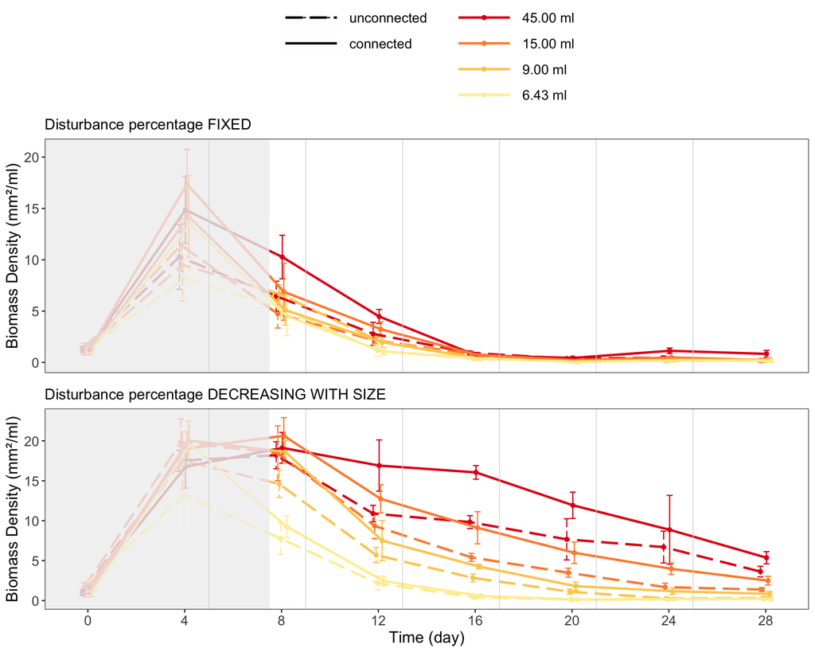

```r
# --- PLOT ORIGINAL DATA MEAN ± 95 % CI --- #

ggarrange(plot.metaecos.legend(ds_metaecosystems %>% filter(disturbance_percentage == "fixed"),
                              response_variable_selected),
          plot.metaecos.points(ds_metaecosystems %>% filter(disturbance_percentage == "fixed"),
                               response_variable_selected)  +
            rremove("xlab") +
            theme(axis.text.x = element_blank(),
                  axis.ticks.x = element_blank(),
                  legend.position = "none") +
            font("legend.text", size = size_legend) +
            font("ylab", size = size_y_axis) +
            ggtitle(fixed_label),
          plot.metaecos.points(ds_metaecosystems %>%
                                 filter(disturbance_percentage == "decreasing_with_size"),
                               response_variable_selected)  +
            font("xlab", size = size_y_axis) +
            font("ylab", size = size_y_axis) +
            scale_x_continuous(breaks = unique(ds_metaecosystems$day)) +
            theme(legend.position = "none") +
            ggtitle(relative_label),
          heights = c(0.25, 0.6, 0.6),
          nrow = 3,
          align = "v")
```

**Effect sizes using Hedge’s d [WORK IN PROGRESS]**

```r
# --- PLOT ORIGINAL DATA EFFECT SIZES (HEDGE'S D) --- #

ggarrange(plot.metaecos.points.ES.legend(ds_metaecos_es %>%
                                           filter(disturbance_percentage == "fixed"),
                                         paste0(response_variable_selected, "_d")),
          plot.metaecos.points.ES(ds_metaecos_es %>% filter(disturbance_percentage == "fixed"),
                                  paste0(response_variable_selected, "_d")) +
            rremove("xlab") +
            theme(axis.text.x = element_blank(),
                  axis.ticks.x = element_blank(),
                  legend.position = "none") +
            font("legend.text", size = size_legend) +
            font("ylab", size = size_y_axis) +
            ggtitle(fixed_label),
          plot.metaecos.points.ES(ds_metaecos_es %>%
                                    filter(disturbance_percentage == "decreasing_with_size"),
                                  paste0(response_variable_selected, "_d")) +
            font("legend.text", size = size_legend) +
            font("xlab", size = size_y_axis) +
            font("ylab", size = size_y_axis) +
            ggtitle(relative_label) +
            scale_x_continuous(breaks = unique(ds_metaecosystems$day)) +
            theme(legend.position = "none"),
          heights = c(0.2, 0.6, 0.6),
          nrow = 3,
          align = "v")
```

[output not shown]

**Effect sizes using log response ratio [WORK IN PROGRESS]**

**A plot per ecosystem size - means**

```r
# --- PLOT ORIGINAL DATA MEAN ± 95 % CI WITH ONE PLOT PER ECOSYSTEM SIZE --- #

sizes = unique(ds_metaecosystems$ecosystem_size_ml)
p = NULL

"Disturbance percentage FIXED"
```

```
## [1] "Disturbance percentage FIXED"
```

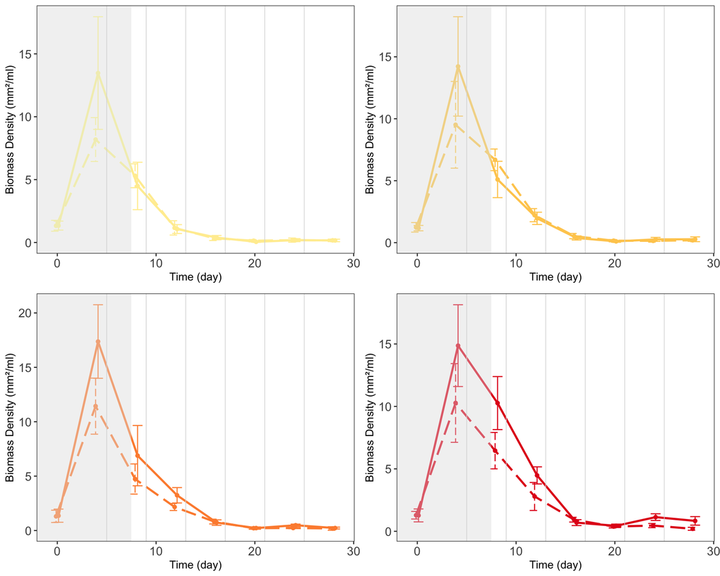

```r
for(ecosystem_size_ml_i in 1:length(sizes)){

  p[[ecosystem_size_ml_i]] = plot.metaecos.points(ds_metaecosystems %>%
                                                    filter(disturbance_percentage == "fixed",
                                                           ecosystem_size_ml == sizes[ecosystem_size_ml_i]),
                                                  response_variable_selected) +
    theme(legend.position = "none")

}

gridExtra::grid.arrange(p[[1]],
                        p[[2]],
                        p[[3]],
                        p[[4]],
                        nrow = 2,
                        ncol = 2)
```